# Problema 4: Estimación de intervalos de confianza

Simulación, Estimación e Inferencia Estadística · 2026-A

Integrantes: Juan Alejandro Carrillo Jaimes & David Burgoa

2026-03-22

# 1 Descripción del Problema

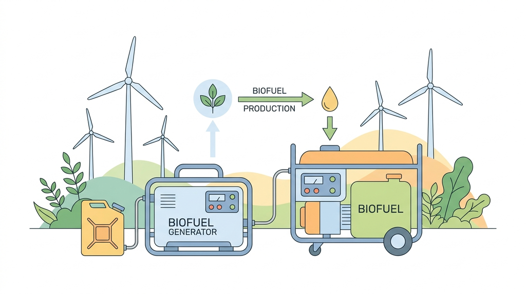

Una empresa dedicada a la generación de energía renovable desea evaluar el rendimiento de sus 20 generadores eléctricos portátiles, alimentados con biocombustible. Estos generadores se utilizan en proyectos remotos, donde la eficiencia energética es crucial para minimizar costos y reducir la huella ambiental. Para el estudio, se mide la eficiencia energética de cada generador, expresada en kilovatios-hora por litro de combustible (kWh/L).

**Objetivo**: Determinar intervalos de confianza al 95% para la eficiencia media.

## 1.1 Normalidad

Antes de calcular intervalos de confianza paramétricos, se verifica si la muestra de eficiencia energética proviene de una población normal.

```r
muestra <- c(6.12, 5.87, 5.45, 6.33, 5.71, 6.04, 5.92, 5.65, 6.18,
             5.78, 5.95, 6.21, 5.63, 5.79, 6.11, 5.88, 6.02, 5.76,
             5.85, 6.10)

n_p4  <- length(muestra)
media <- mean(muestra)
desv  <- sd(muestra)
err   <- desv / sqrt(n_p4)

tabla_desc <- data.frame(
  Estadistico = c("$n$", "$\\bar{x}$", "$s$", "$s/\\sqrt{n}$"),
  Valor       = c(as.character(n_p4),
                  round(media, 4),
                  round(desv, 4),
                  round(err, 4)),
  Unidad      = c("observaciones", "kWh/L", "kWh/L", "kWh/L")
)

knitr::kable(tabla_desc,
  caption   = "Estadísticos descriptivos — eficiencia energética",
  col.names = c("Estadístico", "Valor", "Unidad"),
  align     = c("c", "c", "l"),
  format    = "html",
  escape    = FALSE
) |>
  kableExtra::kable_styling(
    bootstrap_options = c("striped", "hover", "condensed"),
    full_width        = FALSE,
    position          = "center",
    font_size         = 14
  )
```

Table 1.1: Estadísticos descriptivos — eficiencia energética

| Estadístico | Valor | Unidad |
| --- | --- | --- |
| $n$ | 20 | observaciones |
| $\bar{x}$ | 5.9175 | kWh/L |
| $s$ | 0.2232 | kWh/L |
| $s/\sqrt{n}$ | 0.0499 | kWh/L |

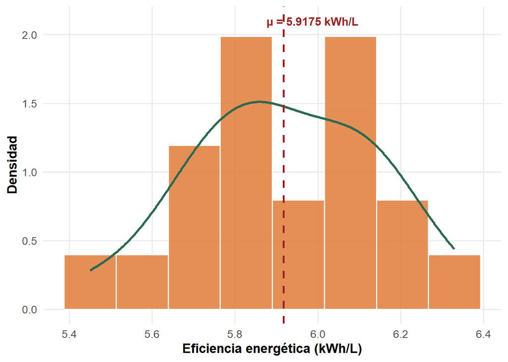

Figure 1.2: Histograma y curva de densidad — eficiencia energética (kWh/L)

```r
df_p4 <- data.frame(x = muestra)

ggplot(df_p4, aes(x = x)) +
  geom_histogram(aes(y = after_stat(density)),
                 bins  = 8,
                 fill  = "#e07b39",
                 color = "white",
                 alpha = 0.85) +
  geom_density(color = "#2d6a4f", linewidth = 1.2) +
  geom_vline(xintercept = media, linetype = "dashed",
             color = "#9b2226", linewidth = 1) +
  annotate("text", x = media + 0.07, y = 2.1,
           label = paste0("\u03bc = ", round(media, 4), " kWh/L"),
           color = "#9b2226", size = 4, fontface = "bold") +
  labs(
    x = "Eficiencia energética (kWh/L)",
    y = "Densidad"
  ) +
  theme_minimal(base_size = 13) +
  theme(
    panel.grid.minor = element_blank(),
    axis.title       = element_text(face = "bold")
  )
```

```r
test_p4 <- shapiro.test(muestra)

# Tabla de hipótesis
tabla_norm_p4 <- data.frame(
  Hipotesis   = c("$H_0$", "$H_1$"),
  Descripcion = c("La muestra proviene de una población normal",
                  "La muestra no proviene de una población normal")
)

knitr::kable(tabla_norm_p4,
  caption   = "Hipótesis del test de normalidad",
  col.names = c("Hipótesis", "Descripción"),
  align     = c("c", "l"),
  format    = "html",
  escape    = FALSE
) |>
  kableExtra::kable_styling(
    bootstrap_options = c("striped", "hover", "condensed"),
    full_width        = FALSE,
    position          = "center",
    font_size         = 14
  )
```

Table 1.2: Hipótesis del test de normalidad

| Hipótesis | Descripción |
| --- | --- |
| $H_0$ | La muestra proviene de una población normal |
| $H_1$ | La muestra no proviene de una población normal |

```r
# Tabla de resultados
tabla_res_p4 <- data.frame(
  Prueba     = "Shapiro-Wilk",
  W          = round(test_p4$statistic, 4),
  p_valor    = round(test_p4$p.value, 4),
  Alpha      = 0.05,
  Conclusion = ifelse(test_p4$p.value > 0.05,
                      "No se rechaza H\u2080 \u2014 normalidad",
                      "Se rechaza H\u2080 \u2014 no normalidad")
)
rownames(tabla_res_p4) <- NULL

knitr::kable(tabla_res_p4,
  caption   = "Resultado del test de normalidad Shapiro-Wilk",
  col.names = c("Prueba", "W", "p-valor", "\u03b1", "Conclusión"),
  align     = c("l", "c", "c", "c", "l"),
  format    = "html"
) |>
  kableExtra::kable_styling(
    bootstrap_options = c("striped", "hover", "condensed"),
    full_width        = FALSE,
    position          = "center",
    font_size         = 14
  )
```

Table 1.3: Resultado del test de normalidad Shapiro-Wilk

| Prueba | W | p-valor | α | Conclusión |
| --- | --- | --- | --- | --- |
| Shapiro-Wilk | 0.9884 | 0.9955 | 0.05 | No se rechaza H₀ — normalidad |

La Figura 1.2 muestra una distribución aproximadamente simétrica y acampanada, centrada en $\bar{x} = 5.9175$ kWh/L, lo que sugiere visualmente que la población podría ser normal.

La Tabla 1.3 confirma esto: el test de Shapiro-Wilk arrojó $W = 0.9884$ y un p-valor de $0.9955$, muy superior a $\alpha = 0.05$. Por lo tanto, **no se rechaza $H_0$**, lo que indica que la muestra proviene de una población normal. Esto valida el uso de métodos paramétricos para calcular el intervalo de confianza.

## 1.2 Método paramétrico

Dado que en el Punto 1 se verificó que la muestra proviene de una población normal ($W = 0.9884$, $p = 0.9955 > \alpha = 0.05$), se cumplen las condiciones para aplicar un intervalo de confianza paramétrico. Como la varianza poblacional $\sigma^2$ es desconocida y $n = 20 < 30$, según la Tabla 2.9 del módulo se utiliza la distribución $t$ de Student con $v = n - 1 = 19$ grados de libertad:

$$\bar{x} \pm t_{\alpha/2,\, v} \cdot \frac{s}{\sqrt{n}}$$

```r
alpha_ic  <- 0.05
t_critico <- qt(1 - alpha_ic / 2, df = n_p4 - 1)

li_t <- media - t_critico * (desv / sqrt(n_p4))
ls_t <- media + t_critico * (desv / sqrt(n_p4))

tabla_ic_t <- data.frame(
  Metodo    = "t de Student",
  gl        = n_p4 - 1,
  t_critico = round(t_critico, 4),
  LI        = round(li_t, 4),
  Media     = round(media, 4),
  LS        = round(ls_t, 4),
  Amplitud  = round(ls_t - li_t, 4)
)

knitr::kable(tabla_ic_t,
  caption   = "Intervalo de confianza paramétrico al 95% — t de Student",
  col.names = c("Método", "g.l.", "t crítico",
                "Límite inferior", "Media", "Límite superior", "Amplitud"),
  align     = c("l","c","c","c","c","c","c"),
  format    = "html"
) |>
  kableExtra::kable_styling(
    bootstrap_options = c("striped","hover","condensed"),
    full_width        = FALSE,
    position          = "center",
    font_size         = 14
  )
```

Table 1.4: Intervalo de confianza paramétrico al 95% — t de Student

| Método | g.l. | t crítico | Límite inferior | Media | Límite superior | Amplitud |
| --- | --- | --- | --- | --- | --- | --- |
| t de Student | 19 | 2.093 | 5.813 | 5.9175 | 6.022 | 0.2089 |

Con un nivel de confianza del 95%, el intervalo de confianza paramétrico para la eficiencia media de los generadores es $[5.813, 6.022]$ kWh/L. Esto significa que, si se repitiera el muestreo múltiples veces, aproximadamente el 95% de los intervalos construidos contendrían la verdadero media poblacional. La amplitud del intervalo es de $0.2089$ kWh/L, lo que indica una estimación bastante precisa dado el tamaño muestral de $n = 20$.

La comparación con los intervalos bootstrap se realizará al finalizar el Punto 3.

## 1.3 Procedimiento bootstrap

Se aplican dos métodos bootstrap para estimar el intervalo de confianza al 95% para la media de eficiencia energética: el método **percentil bootstrap** y el método **normal bootstrap**. Se usa $B = 1000$ muestras bootstrap y semilla `set.seed(1005062032)`.

### 1.3.1 Intervalo percentil bootstrap

Se eligen los métodos **percentil bootstrap** y **normal bootstrap** porque:

- El **percentil bootstrap** no asume ninguna forma distribucional y se basa únicamente en los cuantiles empíricos de las medias bootstrap, siendo el método más directo e intuitivo.
- El **normal bootstrap** es adecuado cuando, como en este caso, las medias bootstrap siguen una distribución aproximadamente normal, consistente con el TLC para $B = 1000$ remuestras.

Se descarta el método BCa por su mayor complejidad computacional y porque la simetría observada en los datos no lo hace necesario.

El intervalo percentil bootstrap se obtiene ordenando las $B = 1000$ medias bootstrap y tomando los percentiles $\alpha/2$ y $1 - \alpha/2$:

$$IC_{percentil} = \left[\hat{\theta}^*_{\lfloor B \cdot \alpha/2 \rfloor + 1},\;
\hat{\theta}^*_{\lfloor B \cdot (1-\alpha/2) \rfloor}\right] =
\left[\hat{\theta}^*_{26},\; \hat{\theta}^*_{975}\right]$$

```r
set.seed(1005062032) # Codigo: Est Juan Alejandro Carrillo Jaimes
B <- 1000

# Generar B muestras bootstrap y calcular la media de cada una
boot_medias <- replicate(B, mean(sample(muestra, size = n_p4, replace = TRUE)))

# Ordenar las medias bootstrap
boot_sorted <- sort(boot_medias)

# Percentiles para IC al 95%
alpha_boot  <- 0.05
li_perc <- boot_sorted[floor(B * alpha_boot / 2) + 1]
ls_perc <- boot_sorted[floor(B * (1 - alpha_boot / 2))]

tabla_perc <- data.frame(
  Metodo   = "Percentil bootstrap",
  B        = B,
  LI       = round(li_perc, 4),
  Media    = round(mean(boot_medias), 4),
  LS       = round(ls_perc, 4),
  Amplitud = round(ls_perc - li_perc, 4)
)

knitr::kable(tabla_perc,
  caption   = "Intervalo de confianza percentil bootstrap al 95%",
  col.names = c("Método", "B", "Límite inferior",
                "Media bootstrap", "Límite superior", "Amplitud"),
  align     = c("l","c","c","c","c","c"),
  format    = "html"
) |>
  kableExtra::kable_styling(
    bootstrap_options = c("striped","hover","condensed"),
    full_width        = FALSE,
    position          = "center",
    font_size         = 14
  )
```

Table 1.5: Intervalo de confianza percentil bootstrap al 95%

| Método | B | Límite inferior | Media bootstrap | Límite superior | Amplitud |
| --- | --- | --- | --- | --- | --- |
| Percentil bootstrap | 1000 | 5.827 | 5.9199 | 6.0115 | 0.1845 |

### 1.3.2 Intervalo normal bootstrap

El intervalo normal bootstrap utiliza la media y desviación estándar de las medias bootstrap con el valor crítico $z_{\alpha/2} = 1.96$:

```r
# Media y desviación estándar de las medias bootstrap
mean_boot <- mean(boot_medias)
sd_boot   <- sd(boot_medias)

# Valor crítico z
z_critico <- qnorm(1 - alpha_boot / 2)

li_norm <- mean_boot - z_critico * sd_boot
ls_norm <- mean_boot + z_critico * sd_boot

tabla_norm_boot <- data.frame(
  Metodo   = "Normal bootstrap",
  B        = B,
  LI       = round(li_norm, 4),
  Media    = round(mean_boot, 4),
  LS       = round(ls_norm, 4),
  Amplitud = round(ls_norm - li_norm, 4)
)

knitr::kable(tabla_norm_boot,
  caption   = "Intervalo de confianza normal bootstrap al 95%",
  col.names = c("Método", "B", "Límite inferior",
                "Media bootstrap", "Límite superior", "Amplitud"),
  align     = c("l","c","c","c","c","c"),
  format    = "html"
) |>
  kableExtra::kable_styling(
    bootstrap_options = c("striped","hover","condensed"),
    full_width        = FALSE,
    position          = "center",
    font_size         = 14
  )
```

Table 1.6: Intervalo de confianza normal bootstrap al 95%

| Método | B | Límite inferior | Media bootstrap | Límite superior | Amplitud |
| --- | --- | --- | --- | --- | --- |
| Normal bootstrap | 1000 | 5.8263 | 5.9199 | 6.0135 | 0.1872 |

```r
tabla_comp <- data.frame(
  Metodo   = c("t de Student", "Percentil bootstrap", "Normal bootstrap"),
  LI       = c(round(li_t, 4), round(li_perc, 4), round(li_norm, 4)),
  Media    = c(round(media, 4), round(mean(boot_medias), 4), round(mean_boot, 4)),
  LS       = c(round(ls_t, 4), round(ls_perc, 4), round(ls_norm, 4)),
  Amplitud = c(round(ls_t - li_t, 4),
               round(ls_perc - li_perc, 4),
               round(ls_norm - li_norm, 4))
)

knitr::kable(tabla_comp,
  caption   = "Comparación de intervalos de confianza al 95%",
  col.names = c("Método", "Límite inferior", "Media",
                "Límite superior", "Amplitud"),
  align     = c("l","c","c","c","c"),
  format    = "html"
) |>
  kableExtra::kable_styling(
    bootstrap_options = c("striped","hover","condensed"),
    full_width        = FALSE,
    position          = "center",
    font_size         = 14
  )
```

Table 1.7: Comparación de intervalos de confianza al 95%

| Método | Límite inferior | Media | Límite superior | Amplitud |
| --- | --- | --- | --- | --- |
| t de Student | 5.8130 | 5.9175 | 6.0220 | 0.2089 |
| Percentil bootstrap | 5.8270 | 5.9199 | 6.0115 | 0.1845 |
| Normal bootstrap | 5.8263 | 5.9199 | 6.0135 | 0.1872 |

### 1.3.3 Comparación e interpretación

¿Los tres intervalos son similares o presentan diferencias significativas?

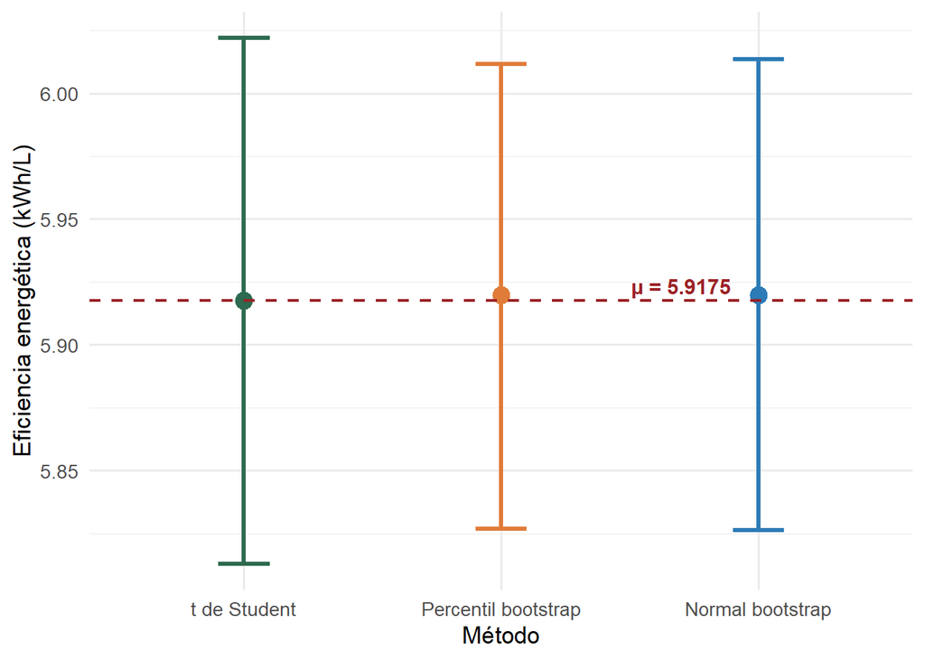

Figure 1.3: Comparación visual de los intervalos de confianza al 95%

```r
df_ic <- data.frame(
  Metodo = factor(c("t de Student", "Percentil bootstrap", "Normal bootstrap"),
                  levels = c("t de Student", "Percentil bootstrap", "Normal bootstrap")),
  Media  = c(round(media, 4), round(mean(boot_medias), 4), round(mean_boot, 4)),
  LI     = c(round(li_t, 4), round(li_perc, 4), round(li_norm, 4)),
  LS     = c(round(ls_t, 4), round(ls_perc, 4), round(ls_norm, 4))
)

ggplot(df_ic, aes(x = Metodo, y = Media, color = Metodo)) +
  geom_point(size = 4) +
  geom_errorbar(aes(ymin = LI, ymax = LS), width = 0.2, linewidth = 1.2) +
  geom_hline(yintercept = media, linetype = "dashed",
             color = "#9b2226", linewidth = 0.8) +
  annotate("text", x = 2.7, y = media + 0.006,
           label = paste0("\u03bc = ", round(media, 4)),
           color = "#9b2226", size = 4, fontface = "bold") +
  scale_color_manual(values = c("#2d6a4f", "#e07b39", "#2c7bb6")) +
  labs(
    x     = "Método",
    y     = "Eficiencia energética (kWh/L)",
    color = "Método"
  ) +
  theme_minimal(base_size = 13) +
  theme(legend.position = "none")
```